# Metamorphic Minerals

Dr. Ahmad Redaa

2024-10-16

# What Are Metamorphic Minerals?

- **Definition**: Minerals that form under elevated pressure and temperature due to metamorphism.
- **Characteristics**:
  - New mineral assemblages due to changes in environmental conditions.
  - Stable only under specific pressure-temperature conditions.
  - Often exhibit foliation or alignment.
- **Examples**: Garnet, Kyanite, Sillimanite, Chlorite, Serpentine, Talc.

# Formation of Metamorphic Minerals

- **Heat**:
  - Promotes recrystallization, resulting in larger and more stable crystals.
- **Pressure**:
  - Causes denser mineral structures and alignment of minerals.
- **Fluids**:
  - Facilitate chemical reactions, leading to new mineral formations.

# Processes of Metamorphic Mineral Formation

- **Recrystallization**:
  - Transformation into more stable mineral forms without changing composition.
- **Phase Changes**:
  - Example: Andalusite transforming into Sillimanite.
- **Metamorphic Reactions**:
  - New mineral assemblages formed by reactions like:
    - Chlorite + Quartz -> Garnet.

# Importance of Studying Metamorphic Minerals

- **Indicator of Pressure-Temperature Conditions**:
  - Kyanite: High-pressure environments.
  - Andalusite: Low-pressure environments.
- **Geological History**:
  - Provides clues to tectonic events and mountain-building processes.
- **Resource Exploration**:
  - Economic value in minerals like garnet (abrasive) and graphite.
  - Metamorphic rocks may host mineral deposits.

# Common Metamorphic Minerals

- **Garnet**: Almandine is typical in medium- to high-grade metamorphism.
- **Kyanite, Sillimanite, Andalusite**: Classic indicators of pressure-temperature conditions.
  - **Kyanite**: High-pressure.
  - **Sillimanite**: High-temperature.
  - **Andalusite**: Low-pressure.
- **Chlorite**: Found in low-grade metamorphic rocks (e.g., greenschist facies).
- **Serpentine and Talc**: Formed by hydration of ultramafic rocks.

# Identifying Metamorphic Grade Using Minerals

- **Index Minerals**:
  - Chlorite: Low-grade.
  - Biotite: Low- to medium-grade.
  - Garnet: Medium-grade.
  - Kyanite, Sillimanite: High-grade.
- **Metamorphic Facies**:
  - Groups of minerals that form under similar conditions:
    - **Greenschist Facies**: Chlorite, Epidote.
    - **Amphibolite Facies**: Garnet, Amphibole.
    - **Granulite Facies**: Pyroxene, Sillimanite.

# Metamorphic Mineral Diagrams

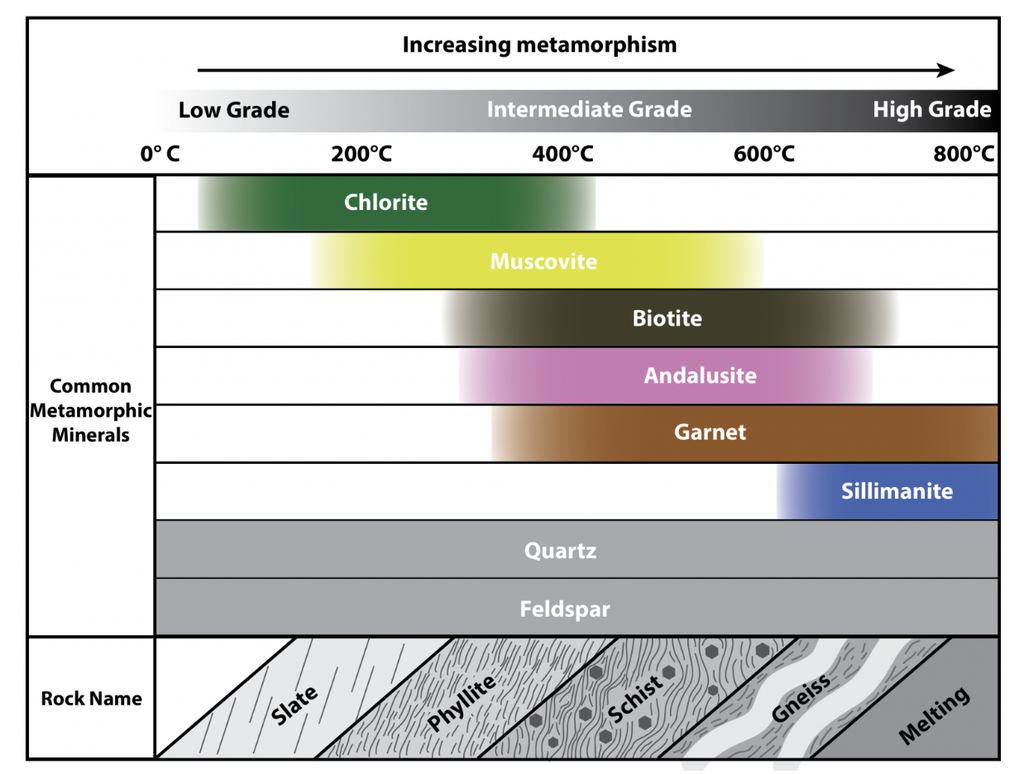

Source: [(McGoldrick, S., 2021)](https://pressbooks.openeducationalberta.ca/practicalgeology/chapter/6-2-classification-of-metamorphic-rocks/)